# Análise de Vendas - Produtos de Petróleo - ANP

Data Analysis

Felipe Daiha Alves

2022-11-28

# 1 **Disclaimer**:

Relatório da etapa de *data analysis* contendo informações e resultados sobre o processo de **Análise de Vendas** de produtos derivados de petróleo.

# 2 **Objetivo**:

# 3 **Pipeline**:

## 3.1 . **Configuração de Ambiente & Data Cleaning**:

Etapa inicial de processamento de dados. Nele, iremos configurar nosso ambiente de desenvolvimento e tratar a base de dados inicialmente para análise posterior.

1. **Configurando Ambiente**  
   (Instalando e/ou carregando pacotes necessários e ajuste de opções de visualização.)

```r
# Nome dos pacotes

packages <- c(
  'rgl', ## Configuracao em RMarkdown
  'data.table', 'arrow', 'GetBCBData',  ## Leitura de dados
  'readr', 'dplyr', 'tidyr', 'janitor', 'zoo', 'lubridate', ## Manipulacao de Dados
  'ggplot2', 'gridExtra', 'scales', 'ggcorrplot' ## Visualizacao de Dados
  )


# Instalando pacotes (caso ainda nao esteja)

installed_packages <- packages %in% rownames(installed.packages())
if (any(installed_packages == FALSE)) {
  install.packages(packages[!installed_packages])
}


# Carregando pacotes

invisible(lapply(packages, library, character.only = TRUE))


# Removendo variaveis criadas previamente

rm(packages, installed_packages)


# Configuracoes de visualizacao no markdown

base::options(rgl.useNULL = TRUE, digits = 10, scipen = 999, encoding = "utf-8", dplyr.summarise.inform = FALSE)
rgl::setupKnitr(autoprint = TRUE)
```

2. **Carregando Dados**  
   (Carregamento de arquivo *.csv* e print de estrutura do arquivo para primeiro contato.)

```r
# Load da base de dados

sales_vbbr <- data.table::fread(
  'C:/Users/daiha/OneDrive/Documentos/R/PS/Vibra/vendas-derivados-petroleo-etanol-m3-1990-2022.csv',
  encoding = "UTF-8")


# Visualizacao primaria dos dados

dplyr::glimpse(sales_vbbr)
```

```
## Rows: 84,240
## Columns: 6
## $ ANO                    <int> 1999, 1999, 1999, 1999, 1999, 1999, 1999, 1999,…
## $ MÊS                    <chr> "NOV", "FEV", "SET", "AGO", "MAI", "ABR", "JAN"…
## $ `GRANDE REGIÃO`        <chr> "REGIÃO SUDESTE", "REGIÃO SUDESTE", "REGIÃO NOR…
## $ `UNIDADE DA FEDERAÇÃO` <chr> "MINAS GERAIS", "SÃO PAULO", "SERGIPE", "SERGIP…
## $ PRODUTO                <chr> "ETANOL HIDRATADO", "ETANOL HIDRATADO", "ETANOL…
## $ VENDAS                 <chr> "43356,352", "202406,862", "2744,883", "2661,21…
```

- **Dicionário de Variáveis**
  - *ANO* <> Ano da Venda
  - *MES* <> Mês da Venda
  - *GRANDE REGIÃO* <> Região da Venda
  - *UNIDADE DA FEDERAÇÃO* <> Estado da Venda
  - *PRODUTO* <> Produto Vendido
  - *VENDAS* <> Volume Total (m³)
3. **Tratamento Inicial**  
   (Com nossos dados devidamente carregados, podemos começar o processo de tratamento e limpeza de dados. Primeiro, verificaremos as classes de cada feature do dataset.)

```r
# Verificando classes das variaveis

lapply(sales_vbbr %>% dplyr::select(!c(VENDAS)), table)
```

```
## $ANO
##
## 1990 1991 1992 1993 1994 1995 1996 1997 1998 1999 2000 2001 2002 2003 2004 2005
## 2592 2592 2592 2592 2592 2592 2592 2592 2592 2592 2592 2592 2592 2592 2592 2592
## 2006 2007 2008 2009 2010 2011 2012 2013 2014 2015 2016 2017 2018 2019 2020 2021
## 2592 2592 2592 2592 2592 2592 2592 2592 2592 2592 2592 2592 2592 2592 2592 2592
## 2022
## 1296
##
## $MÊS
##
##  ABR  AGO  DEZ  FEV  JAN  JUL  JUN  MAI  MAR  NOV  OUT  SET
## 7128 6912 6912 7128 7128 6912 7128 7128 7128 6912 6912 6912
##
## $`GRANDE REGIÃO`
##
## REGIÃO CENTRO-OESTE     REGIÃO NORDESTE        REGIÃO NORTE      REGIÃO SUDESTE
##               12480               28080               21840               12480
##          REGIÃO SUL
##                9360
##
## $`UNIDADE DA FEDERAÇÃO`
##
##                ACRE             ALAGOAS               AMAPÁ            AMAZONAS
##                3120                3120                3120                3120
##               BAHIA               CEARÁ    DISTRITO FEDERAL      ESPÍRITO SANTO
##                3120                3120                3120                3120
##               GOIÁS            MARANHÃO         MATO GROSSO  MATO GROSSO DO SUL
##                3120                3120                3120                3120
##        MINAS GERAIS                PARÁ             PARAÍBA              PARANÁ
##                3120                3120                3120                3120
##          PERNAMBUCO               PIAUÍ      RIO DE JANEIRO RIO GRANDE DO NORTE
##                3120                3120                3120                3120
##   RIO GRANDE DO SUL            RONDÔNIA             RORAIMA      SANTA CATARINA
##                3120                3120                3120                3120
##           SÃO PAULO             SERGIPE           TOCANTINS
##                3120                3120                3120
##
## $PRODUTO
##
##     ETANOL HIDRATADO           GASOLINA C  GASOLINA DE AVIAÇÃO
##                10530                10530                10530
##                  GLP     ÓLEO COMBUSTÍVEL          ÓLEO DIESEL
##                10530                10530                10530
## QUEROSENE DE AVIAÇÃO QUEROSENE ILUMINANTE
##                10530                10530
```

(Em seguida, começamos a tratar as variáveis individualmente (se necessario), printando na tela o produto final dessa etapa.)

```r
# 1 - Convertendo variaveis necessarias (VENDAS para 'numeric' e MÊS para formato 'integer')

sales_vbbr <- sales_vbbr %>%
  dplyr::mutate(
    VENDAS = readr::parse_number(
      x = VENDAS,
      locale = locale(decimal_mark = ",", grouping_mark = ".")))

# 2 - Pivoteando PRODUTO (linha -> coluna)

sales_vbbr <- sales_vbbr %>%
  tidyr::pivot_wider(
    names_from = PRODUTO,
    values_from = VENDAS,
    values_fill = 0,
    names_prefix = "vendas_")

# 3 - Retirando espaco vazio do nome das colunas

sales_vbbr <- janitor::clean_names(sales_vbbr) %>%
  dplyr::mutate(mes = numeric_mon(mes))

# Printando na tela resultado do tratamento

dplyr::glimpse(sales_vbbr)
```

```
## Rows: 10,530
## Columns: 12
## $ ano                         <int> 1999, 1999, 1999, 1999, 1999, 1999, 1999, …
## $ mes                         <int> 11, 2, 9, 8, 5, 4, 1, 3, 7, 10, 12, 10, 11…
## $ grande_regiao               <chr> "REGIÃO SUDESTE", "REGIÃO SUDESTE", "REGIÃ…
## $ unidade_da_federacao        <chr> "MINAS GERAIS", "SÃO PAULO", "SERGIPE", "S…
## $ vendas_etanol_hidratado     <dbl> 43356.352, 202406.862, 2744.883, 2661.218,…
## $ vendas_gasolina_c           <dbl> 184870.132, 600213.120, 11516.021, 11731.4…
## $ vendas_gasolina_de_aviacao  <dbl> 149.157, 2650.826, 0.081, 0.252, 1894.763,…
## $ vendas_glp                  <dbl> 110763.336400, 249149.980000, 7934.361818,…
## $ vendas_querosene_de_aviacao <dbl> 7688.539, 178005.341, 975.061, 930.806, 18…
## $ vendas_querosene_iluminante <dbl> 527.573, 1211.112, 10.000, 0.000, 1525.807…
## $ vendas_oleo_combustivel     <dbl> 120945.0755000, 281350.7735000, 5776.19795…
## $ vendas_oleo_diesel          <dbl> 369455.142, 544525.246, 17148.543, 17450.9…
```

**Comments:** A ideia de pivotear as vendas dos produtos como coluna auxiliará na etapa de EDA, além de reduzir o shape do dataset para o formato desejado.  
(Avaliando se há valores faltantes evidentes na base de dados.)

```r
# Checando NAs

sapply(sales_vbbr, function(x) sum(is.na(x)))
```

```
##                         ano                         mes
##                           0                           0
##               grande_regiao        unidade_da_federacao
##                           0                           0
##     vendas_etanol_hidratado           vendas_gasolina_c
##                           0                           0
##  vendas_gasolina_de_aviacao                  vendas_glp
##                           0                           0
## vendas_querosene_de_aviacao vendas_querosene_iluminante
##                           0                           0
##     vendas_oleo_combustivel          vendas_oleo_diesel
##                           0                           0
```

(Por fim, ordenamos nosso dataframe apenas para aspecto visual do problema.)

```r
# Ordenando dataframe para melhor compreensao do problema

sales_vbbr <- sales_vbbr %>%
  dplyr::arrange(ano, mes, grande_regiao, unidade_da_federacao)


# Print na tela

head(sales_vbbr, 20)
```

```
## # A tibble: 20 × 12
##      ano   mes grande_…¹ unida…² venda…³ venda…⁴ venda…⁵ venda…⁶ venda…⁷ venda…⁸
##    <int> <int> <chr>     <chr>     <dbl>   <dbl>   <dbl>   <dbl>   <dbl>   <dbl>
##  1  1990     1 REGIÃO C… DISTRI…  23811.  20587.  227.     8431.  21487.   40.8
##  2  1990     1 REGIÃO C… GOIÁS    29876.  23973.  665.    33953.   1894.  368.
##  3  1990     1 REGIÃO C… MATO G…  16480.  15853. 1509.    17439.   3531.   16.4
##  4  1990     1 REGIÃO C… MATO G…  15539.  15122.  558.    15095.   1956.   51.3
##  5  1990     1 REGIÃO N… ALAGOAS  10091.   5620.   47.9    9439.   2732.  275.
##  6  1990     1 REGIÃO N… BAHIA    53118.  31740.  494.    47843.  10876. 3593.
##  7  1990     1 REGIÃO N… CEARÁ    18160.  15414.  173.    21607.   9388. 1174.
##  8  1990     1 REGIÃO N… MARANH…   7579.   4947.  192.    11311.   4710.  390.
##  9  1990     1 REGIÃO N… PARAÍBA   9857.   7839.    0     11413.   3959   326.
## 10  1990     1 REGIÃO N… PERNAM…  31060.  22430.  306.    28893.  23564. 1233.
## 11  1990     1 REGIÃO N… PIAUÍ     4138.   3724.   56.3    8081.   1359.  413.
## 12  1990     1 REGIÃO N… RIO GR…   9990.   7224.    9.57  11517.   2490.   96.0
## 13  1990     1 REGIÃO N… SERGIPE   6053.   4583.   26.4    5995.   5967.   64.0
## 14  1990     1 REGIÃO N… ACRE       861.   1142.   61.1    1310.    911.   20.0
## 15  1990     1 REGIÃO N… AMAPÁ      713.    848.   51.9    1150.    787.    6.34
## 16  1990     1 REGIÃO N… AMAZON…   5396.   6767.  649.     7362.  20706.  267.
## 17  1990     1 REGIÃO N… PARÁ     10715.   9357. 1561.    17316.  13465.  928.
## 18  1990     1 REGIÃO N… RONDÔN…   3892.   5649.  147.     5210.   1343.   51.5
## 19  1990     1 REGIÃO N… RORAIMA    720.   1575.  577.      761.    554.    1.22
## 20  1990     1 REGIÃO N… TOCANT…   3046.   2042.   79.5    7677.    124.   35.5
## # … with 2 more variables: vendas_oleo_combustivel <dbl>,
## #   vendas_oleo_diesel <dbl>, and abbreviated variable names ¹grande_regiao,
## #   ²unidade_da_federacao, ³vendas_etanol_hidratado, ⁴vendas_gasolina_c,
## #   ⁵vendas_gasolina_de_aviacao, ⁶vendas_glp, ⁷vendas_querosene_de_aviacao,
## #   ⁸vendas_querosene_iluminante
```

**Comments:** A etapa de tratamento e limpeza dos dados não pode ser dado como concluída. A medida que for feita a exploratória dos dados, pode-se ainda identificar *outliers* que poderão ser tratados conforme cada particularidade das *features*. É uma análise constantemente retomada durante uma *pipeline* de ciência de dados.

## 3.2 . **Análise Exploratória de Dados**:

Fase de análise dos dados. A finalidade dessa etapa é compreender padrões e correlações que nos auxiliem a identificar variáveis para discriminação de **Vendas de Gasolina C**.  
Em um primeiro momento, apenas iremos estudar o dataset fornecido, guiando nossa busca de dados externos conforme os *insights* retirados dessa fase do projeto.

1. **Sumário Estatístico**  
   (Sumário de dados das variáveis numéricas que compõem o conjunto de dados)

```r
# Estatisticas basicas para verificacao de intervalos

summary(sales_vbbr %>% dplyr::select(where(is.numeric)))
```

```
##       ano                mes            vendas_etanol_hidratado
##  Min.   :1990.000   Min.   : 1.000000   Min.   :      0.000
##  1st Qu.:1998.000   1st Qu.: 3.000000   1st Qu.:   2496.155
##  Median :2006.000   Median : 6.000000   Median :   6726.359
##  Mean   :2005.754   Mean   : 6.453846   Mean   :  33519.411
##  3rd Qu.:2014.000   3rd Qu.: 9.000000   3rd Qu.:  21335.741
##  Max.   :2022.000   Max.   :12.000000   Max.   :1077621.990
##  vendas_gasolina_c    vendas_gasolina_de_aviacao   vendas_glp
##  Min.   :      5.00   Min.   : -56.76929         Min.   :   356.2264
##  1st Qu.:  14846.10   1st Qu.:  31.77467         1st Qu.:  9950.5100
##  Median :  38487.80   Median :  81.59350         Median : 16425.9783
##  Mean   :  85132.78   Mean   : 196.44017         Mean   : 37088.4681
##  3rd Qu.:  97494.44   3rd Qu.: 226.89425         3rd Qu.: 45073.9832
##  Max.   :1025739.21   Max.   :3219.49500         Max.   :336941.5873
##  vendas_querosene_de_aviacao vendas_querosene_iluminante
##  Min.   :     0.000          Min.   :   -0.1200
##  1st Qu.:  1508.084          1st Qu.:    0.0000
##  Median :  4221.926          Median :   21.4250
##  Mean   : 15644.749          Mean   :  296.4146
##  3rd Qu.: 12615.924          3rd Qu.:  217.6750
##  Max.   :291657.348          Max.   :14817.4030
##  vendas_oleo_combustivel vendas_oleo_diesel
##  Min.   :     0.00       Min.   :      0.00
##  1st Qu.:   100.59       1st Qu.:  29274.06
##  Median :  3976.36       Median :  68009.38
##  Mean   : 19773.48       Mean   : 132214.86
##  3rd Qu.: 24530.73       3rd Qu.: 165921.09
##  Max.   :514131.22       Max.   :1272781.40
```

**Comments:** Entre os principais aspectos que chamam atenção aqui são:

- **1 - Volume de Vendas Negativo?**: > O modelo de negócio é novo pra mim, mas ao meu ver não é possível que haja volume total de vendas negativo. Uma outra hipótese é que isso signifique uma **Devolução** do produto, correspondendo a um saldo negativo nas vendas. Para ambos os casos, devido à particularidade, iremos converter para um volume total de **0**;
- **2 - Distribuições de Volumes** > É notável que a **demanda pelos produtos é diferente** conforme amplitude absoluta entre os quartis e valores máximos obtidos pelas vendas dos produtos;

```r
# Tratando casos de volumes de vendas negativos no dataframe

sales_vbbr <- sales_vbbr %>%
  dplyr::mutate(
    dplyr::across(c(
      where(is.numeric)),
      ~base::ifelse(.x < 0, 0, .x)
    )
  )
```

2. **Corrplot entre Vendas de Produtos**  
   (Plot da matriz de correlação entre as variáveis numéricas de vendas.)

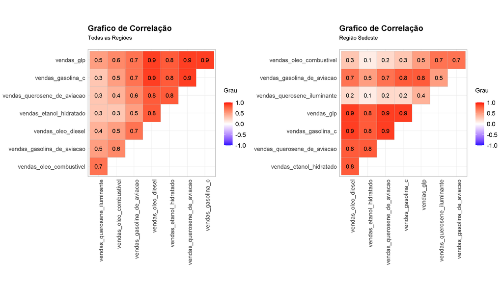

```r
# Criando uma matrix de Correlacao de pearson e realizando ajustes no grafico

gridExtra::grid.arrange(
  corr_plot(sales_vbbr, "Todas as Regiões"),
  corr_plot(sales_vbbr %>% dplyr::filter(grande_regiao == "REGIÃO SUDESTE"), "Região Sudeste"),
  ncol = 2, nrow = 1)
```

```r
# Selecionando apenas variáveis de interesse

sales_vbbr <- sales_vbbr %>%
  dplyr::select(ano, mes, grande_regiao, unidade_da_federacao, vendas_etanol_hidratado, vendas_gasolina_c)
```

[output not shown]

(Plot do volume de vendas desses 2 produtos para efeito comparativo).

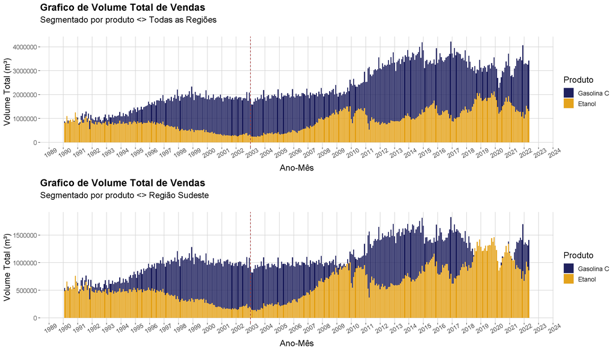

```r
# Criando grafico de barras para visualizacao de vendas

gridExtra::grid.arrange(
  barplot_sales(sales_vbbr, "Segmentado por produto <> Todas as Regiões"),
  barplot_sales(sales_vbbr %>% dplyr::filter(grande_regiao == "REGIÃO SUDESTE"), "Segmentado por produto <> Região Sudeste"),
  ncol = 1, nrow = 2)
```

```r
# Adicionando feature year_mon

sales_vbbr <- sales_vbbr %>%
  dplyr::mutate(year_mon = yyyy_mm(ano, mes))
```

```r
# Selecionando apenas variáveis de interesse

sales_vbbr <- sales_vbbr %>%
  dplyr::filter(year_mon >= "2003-03-01")
```

4. **Web Scrapping - Preços ANP**  
   (Rodando código elaborado pra scrapping do dataset *Série Histórica de Preços de Combustíveis*. Retirado da URL: https://www.gov.br/anp/pt-br/centrais-de-conteudo/dados-abertos/serie-historica-de-precos-de-combustiveis).

```r
# list_dates <- c(unique(sales_vbbr$year_mon))
#
# for (i in list_dates) {
#
#   ## Lendo arquivo
#
#   base <- try(
#     data.table::fread(
#       paste0(
#         "https://www.gov.br/anp/pt-br/centrais-de-conteudo/dados-abertos/arquivos/shpc/dsas/ca/ca-", i, ".csv"),
#       showProgress = TRUE))
#
#   ## Se 'data' nao for da classe dataframe, next
#
#   if(sum(class(base) %in% "try-error" == TRUE) > 0){
#
#     rm(base)
#
#   } else { ## Se nao retornar erro, entao salvar os dados
#
#     ## Salvando dados publicos localmente no formato .parquet
#
#     arrow::write_parquet(
#       base,
#       sink = paste0(
#         "C:/Users/daiha/OneDrive/Documentos/R/PS/Vibra/aux_datasets/precos_combustiveis/ca_", i, ".parquet"))
#
#     ## Removendo variavel do loop
#
#     rm(base)
#
#   }
#
# }
```

(Puxando dados de *Preço de Venda* nas revendedoras por região, estado, produto e ano-mes).

```r
price_dataset <- price_func()
```

```
## [1] "Dataset >200401< sumarizado com sucesso!"
## [1] "Dataset >200402< sumarizado com sucesso!"
## [1] "Dataset >200501< sumarizado com sucesso!"
## [1] "Dataset >200502< sumarizado com sucesso!"
## [1] "Dataset >200601< sumarizado com sucesso!"
## [1] "Dataset >200602< sumarizado com sucesso!"
## [1] "Dataset >200701< sumarizado com sucesso!"
## [1] "Dataset >200702< sumarizado com sucesso!"
## [1] "Dataset >200801< sumarizado com sucesso!"
## [1] "Dataset >200802< sumarizado com sucesso!"
## [1] "Dataset >200901< sumarizado com sucesso!"
## [1] "Dataset >200902< sumarizado com sucesso!"
## [1] "Dataset >201001< sumarizado com sucesso!"
## [1] "Dataset >201002< sumarizado com sucesso!"
## [1] "Dataset >201101< sumarizado com sucesso!"
```

[output cut: 21 more lines]

**Comments:** O dataset confere o preço de venda que **cada posto realizou a comercialização** dos diversos produtos nos postos de abastecimento. Será utilizado o mesmo racional de agrupamento, pegando a **média do preço praticado** para Gasolina Comum e Etanol Hidratado.  
(Tratando base principal para join)

```r
# Ajuste de variaveis para join entre datasets

sales_vbbr <- sales_vbbr %>%
  dplyr::mutate(
    grande_regiao = region_abv(grande_regiao),
    unidade_da_federacao = state_abv(unidade_da_federacao)) %>%
  dplyr::inner_join(
    price_dataset %>%
      dplyr::mutate(year_mon = as.Date(year_mon)),
    by = c(
      "grande_regiao" = "regiao_sigla",
      "unidade_da_federacao" = "estado_sigla",
      "year_mon" = "year_mon"
      ))

# Removendo base de precos

rm(price_dataset)

# Print de resultado

dplyr::glimpse(sales_vbbr)
```

```
## Rows: 5,669
## Columns: 9
## $ ano                           <int> 2004, 2004, 2004, 2004, 2004, 2004, 2004…
## $ mes                           <int> 5, 5, 5, 5, 5, 5, 5, 5, 5, 5, 5, 5, 5, 5…
## $ grande_regiao                 <chr> "CO", "CO", "CO", "CO", "NE", "NE", "NE"…
## $ unidade_da_federacao          <chr> "DF", "GO", "MT", "MS", "AL", "BA", "CE"…
## $ vendas_etanol_hidratado       <dbl> 6225.922, 15017.495, 5158.432, 5901.304,…
## $ vendas_gasolina_c             <dbl> 57218.569, 69996.023, 29303.178, 26522.6…
## $ year_mon                      <date> 2004-05-01, 2004-05-01, 2004-05-01, 200…
## $ media_valor_de_venda_ETANOL   <dbl> 1.3028967495, 1.0965353824, 1.3427362637…
## $ media_valor_de_venda_GASOLINA <dbl> 2.034324427, 2.005137955, 2.338270479, 2…
```

5. **Avaliação Preço & Vendas dos Produtos**  
   (Validando hipótese demanda-preco ao comparar Gasolina C e Etanol)

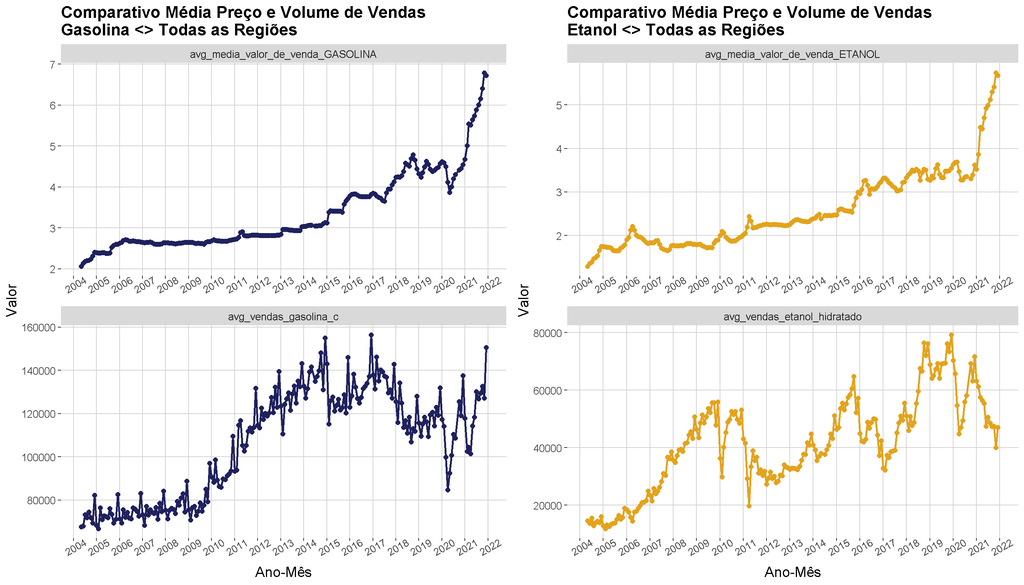

```r
# Plot em conjunto comparando preco e demanda dos produtos GASOLINA C e Etanol

gridExtra::grid.arrange(
  sales_price_comparative(
    df = sales_vbbr,
    vars = c("media_valor_de_venda_GASOLINA", "vendas_gasolina_c"),
    title = "Gasolina <> Todas as Regiões",
    colour = "#1F215E"),
  sales_price_comparative(
    df = sales_vbbr,
    vars = c("media_valor_de_venda_ETANOL", "vendas_etanol_hidratado"),
    title = "Etanol <> Todas as Regiões",
    colour = "#E4A31C"),
  ncol = 2, nrow = 1)
```

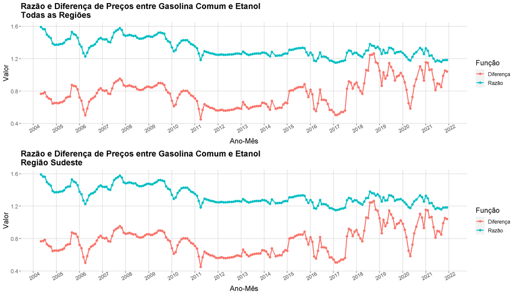

```r
# Plot comparando diferenca e razao de preco medio entre produtos

gridExtra::grid.arrange(
  diff_ratio_comparative(sales_vbbr, "Todas as Regiões"),
  diff_ratio_comparative(sales_vbbr %>% dplyr::filter(grande_regiao == "SE"), "Região Sudeste"),
  ncol = 1, nrow = 2)
```

6. **API Request - SGS Banco Central**  
   (Chamando API do Banco Central para captura de dados de *Índice de volume de vendas no varejo - total*).

```r
# Chamando datasets pelo codigo das informacoes

vendas_varejo_bcb <- GetBCBData::gbcbd_get_series(
  id = c('AC' = 1457,
         'AL' = 1469,
         'AM' = 1458,
         'AP' = 1461,
         'BA' = 1471,
         'CE' = 1465,
         'DF' = 1482,
         'ES' = 1473,
         'GO' = 1481,
         'MA' = 1463,
         'MG' = 1472,
         'MS' = 1479,
         'MT' = 1480,
         'PA' = 1460,
         'PB' = 1467,
         'PE' = 1468,
         'PI' = 1464,
         'PR' = 1476,
         'RJ' = 1474,
         'RN' = 1466,
         'RO' = 1456,
         'RR' = 1459,
         'RS' = 1478,
         'SC' = 1477,
         'SE' = 1470,
         'SP' = 1475,
         'TO' = 1462), ## Volume de Vendas no Varejo por Estado
  first.date = min(sales_vbbr$year_mon),
  last.date = max(sales_vbbr$year_mon),
  format.data = 'long',
  cache.path = tempdir())

# Renomeando colunas

vendas_varejo_bcb <- vendas_varejo_bcb %>%
  dplyr::select(year_mon = ref.date, volume_vendas_varejo_bcb = value, unidade_da_federacao = series.name)

# Join com a base principal

sales_vbbr <- sales_vbbr %>%
  dplyr::inner_join(
    vendas_varejo_bcb,
    by = c(
      "year_mon", "unidade_da_federacao"
    )
  )

# Dropando base consultada

rm(vendas_varejo_bcb)

# Print na tela dos resultados

dplyr::glimpse(sales_vbbr)
```

```
## Rows: 5,669
## Columns: 10
## $ ano                           <int> 2004, 2004, 2004, 2004, 2004, 2004, 2004…
## $ mes                           <int> 5, 5, 5, 5, 5, 5, 5, 5, 5, 5, 5, 5, 5, 5…
## $ grande_regiao                 <chr> "CO", "CO", "CO", "CO", "NE", "NE", "NE"…
## $ unidade_da_federacao          <chr> "DF", "GO", "MT", "MS", "AL", "BA", "CE"…
## $ vendas_etanol_hidratado       <dbl> 6225.922, 15017.495, 5158.432, 5901.304,…
## $ vendas_gasolina_c             <dbl> 57218.569, 69996.023, 29303.178, 26522.6…
## $ year_mon                      <date> 2004-05-01, 2004-05-01, 2004-05-01, 200…
## $ media_valor_de_venda_ETANOL   <dbl> 1.3028967495, 1.0965353824, 1.3427362637…
## $ media_valor_de_venda_GASOLINA <dbl> 2.034324427, 2.005137955, 2.338270479, 2…
## $ volume_vendas_varejo_bcb      <dbl> 60.39, 47.73, 60.68, 43.94, 37.29, 48.14…
```

**Comments:** Neste dataset, a ideia é que um maior volume de vendas no varejo impacta positivamente na demanda por combustíveis. Afinal, mais vendas no varejo significa maior número de pessoas circulando nas ruas e consequentemente maior número de automóveis e a necessidade de abastecimento dos mesmos. Vamos checar se isso se confirma.

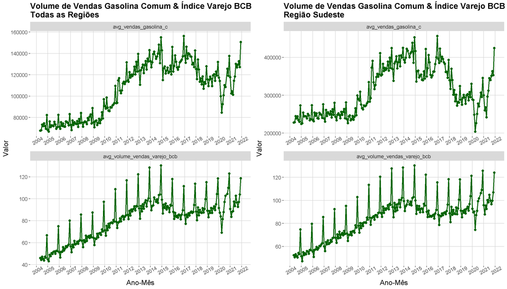

```r
# Criando grafico para analise

gridExtra::grid.arrange(
  anp_bcp_comparative(sales_vbbr, "Todas as Regiões"),
  anp_bcp_comparative(sales_vbbr %>% dplyr::filter(grande_regiao == "SE"), "Região Sudeste"),
  ncol = 2, nrow = 1)
```

**Comments:** Analisando o gráfico gerado, vemos como a hipótese se confirma, tendo os mesmos *trends* em curto prazo. Inclusive, os picos coincidem entre si, em momentos de fim de ano onde o consumo é maior para comemoração de festividades e viagens pessoais.

## 3.3 . **Base de Modelagem**:

Por fim dessa primeira parte, salvaremos nossa base final utilizada para o processo de criação do modelo de previsão.

```r
# Base final

sales_vbbr <- sales_vbbr %>%
  dplyr::select(
    grande_regiao, unidade_da_federacao, year_mon,
    dplyr::starts_with(c("media", "volume", "vendas")))

# Print na tela do shape final do dataframe e sua estrutura

dplyr::glimpse(sales_vbbr)
```

```
## Rows: 5,669
## Columns: 8
## $ grande_regiao                 <chr> "CO", "CO", "CO", "CO", "NE", "NE", "NE"…
## $ unidade_da_federacao          <chr> "DF", "GO", "MT", "MS", "AL", "BA", "CE"…
## $ year_mon                      <date> 2004-05-01, 2004-05-01, 2004-05-01, 200…
## $ media_valor_de_venda_ETANOL   <dbl> 1.3028967495, 1.0965353824, 1.3427362637…
## $ media_valor_de_venda_GASOLINA <dbl> 2.034324427, 2.005137955, 2.338270479, 2…
## $ volume_vendas_varejo_bcb      <dbl> 60.39, 47.73, 60.68, 43.94, 37.29, 48.14…
## $ vendas_etanol_hidratado       <dbl> 6225.922, 15017.495, 5158.432, 5901.304,…
## $ vendas_gasolina_c             <dbl> 57218.569, 69996.023, 29303.178, 26522.6…
```

```r
# Salvando dados

arrow::write_parquet(
      sales_vbbr,
      sink = paste0(
        "C:/Users/daiha/OneDrive/Documentos/R/PS/Vibra/aux_datasets/cleaned_sales.parquet"))

# Limpando workspace

rm(list = ls())
```